# FastqPlotR Vignette

Jake Sauter

2/19/2021

Welcome to `FastQCPlotR`! The heart of this package is the `reading_in(file,test)` utility that we will soon review, however at a high level this function can aid the user for reading in the results of their `FastQC` runs over NGS data, as well as **plotting** this data!

Before we continue, we will have to import a few packages that this vignette relies on.

```r
library(FastQCPlotR)
library(magrittr)
library(ggplot2)
library(dplyr)
library(knitr)
```

## **Function: reading_in(file, test)**

The heart of the `FastQCPlotR` package is the `reading_in` function. This function takes as arguments:

### **Arguments**

```r
args(reading_in)
```

```
## function (file, test = "Per base sequence quality", sample_name = NULL)
## NULL
```

- `file`: The `FastQC` output file to read in. This file is usually named `fastqc_data.txt` in the output directory of your `FastQC` run.
- `test`: The test results data to read from the `FastQC` results file. By default this is “Per base sequence quality”, however the user can pass any valid `FastQC` section identifier.
- `sample_name`: (optional) A name to give the sample, this name will be appended as a new column to every row.

We can see the function in action, and observe a few resultant rows of output below.

```r
fastqc_data_file <-
   system.file('extdata',
            '/fastqc_files/ERR458493_fastqc_data.txt',
            package = "FastQCPlotR")

reading_in(fastqc_data_file) %>%
   head() %>%
   kable()
```

| Base | Mean | Median | Lower Quartile | Upper Quartile | 10th Percentile | 90th Percentile |
| --- | --- | --- | --- | --- | --- | --- |
| 1 | 30.50709 | 31 | 30 | 33 | 28 | 34 |
| 2 | 28.67558 | 31 | 28 | 31 | 16 | 34 |
| 3 | 27.46926 | 31 | 25 | 31 | 16 | 34 |
| 4 | 31.09976 | 35 | 28 | 37 | 19 | 37 |
| 5 | 33.49616 | 35 | 33 | 37 | 28 | 37 |
| 6 | 34.46542 | 35 | 35 | 37 | 31 | 37 |

Now that we have seen this function in action, we can review how exactly it works. First, lets take a look at the body of the function.

### **Body**

```r
body(reading_in)
```

```
## {
##     syscommand <- paste0("sed -n '/", test, "/,/END_MODULE/p' ",
##         file, " | grep -v '^>>'")
##     df <- data.table::fread(cmd = syscommand, header = TRUE) %>%
##         as.data.frame() %>% rename(Base = `#Base`)
##     if (!is.null(sample_name) && is.character(sample_name)) {
##         df <- cbind(df, sample_name)
##     }
##     else if (!is.character(sample_name)) {
##         message(paste("sample_name parameter must be a character vector!"),
##             " sample_name will not be included!")
##     }
##     return(df)
## }
```

We can see above that the `reading_in()` command makes use of a `Unix` system command making using of `sed`. In order to fully understand what the `reading_in()` function is doing, we will explain the use of `sed` in this context.

Given the functions arguments of `test` and `file`, the function forms a command that will look similar to below for the following inputs:

```r
test = "Per base sequence quality"
file = '/home/x1/Documents/Weill_Cornell/ANGSD/homework/FastQCPlotR/data/ERR458497_fastqc/fastqc_data.txt'

paste0("sed -n '/", test, "/,/END_MODULE/p' ",
        file, " | grep -v '^>>'")
```

```
## [1] "sed -n '/Per base sequence quality/,/END_MODULE/p' /home/x1/Documents/Weill_Cornell/ANGSD/homework/FastQCPlotR/data/ERR458497_fastqc/fastqc_data.txt | grep -v '^>>'"
```

`sed` – stream editor `-n` – silent option

This command is being used to extract the “Per base sequence quality” section from the `fastqc_data.txt` file.

from the sed help: `p Print the current pattern space.`

from section 5.1 of the sed manual `info sed`

```bash
5.1 Overview of regular expression in 'sed'
===========================================

To know how to use 'sed', people should understand regular expressions
("regexp" for short).  A regular expression is a pattern that is matched
against a subject string from left to right.  Most characters are
"ordinary": they stand for themselves in a pattern, and match the
corresponding characters.  Regular expressions in 'sed' are specified
between two slashes.

   The following command prints lines containing the word 'hello':

     sed -n '/hello/p'

   The above example is equivalent to this 'grep' command:

     grep 'hello'
```

This command uses `regular expressions` contained within `/.../` forward slashes to dictate to `sed` the starting and ending patterns, followed by `p` telling `sed` to print all of the lines in this section. This function in particular uses a variable that allows for parsing the file to isolate different sections, with each section always ending with `END_MODULE`.

### **Use Case**

We will now use the `reading_in` function to read in the FastQC results of at 4 fastq files (2 biological replicates and 2 technical replicates each). We will make use of the `sample_name` argument to `reading_in` to keep track of the sample name in the new R objects we are creating.

First we will select the files from the `sample_mapping.tsv` file included in the package to simulate a real NGS workflow. We will load in this runs accession table and filter for only those samples that we are interested in. For this use case, we will be using `WT_1` and `WT_2` **biological replicates**, as well as the **technical replicates** sequenced in both lanes 1 and 2 for both biological replicates.

```r
samp_map_file <- system.file("extdata", 'sample_mapping.tsv', package="FastQCPlotR")

sample_mapping <- read.csv(samp_map_file, sep = '\t')

samples <- sample_mapping[sample_mapping$Sample == "WT" &
               sample_mapping$Lane %in% c(1,2) &
               sample_mapping$BiolRep %in% c(1,2), ]

samples %>% kable()
```

|  | RunAccession | Lane | Sample | BiolRep |
| --- | --- | --- | --- | --- |
| 1 | ERR458493 | 1 | WT | 1 |
| 2 | ERR458494 | 2 | WT | 1 |
| 344 | ERR458878 | 1 | WT | 2 |
| 345 | ERR458879 | 2 | WT | 2 |

Now that we have isolated our samples of interest, we can access the `FastQC` files associated with them. For this case we have included some raw data in the package for instructional purposes, though this is where the user **should locate their own FastQC files on their file system**.

```r
run_accs <- samples$RunAccession

fastqc_files <-
   system.file("extdata",
      paste0('fastqc_files/', run_accs, '_fastqc_data.txt'),
       package="FastQCPlotR")

names(fastqc_files) <- samples$RunAccession

fastqc_files %>%
   as.data.frame() %>%
   t() %>%
   kable()
```

|  | ERR458493 | ERR458494 | ERR458878 | ERR458879 |
| --- | --- | --- | --- | --- |
| . | /home/x1/R/x86_64-pc-linux-gnu-library/3.6/FastQCPlotR/extdata/fastqc_files/ERR458493_fastqc_data.txt | /home/x1/R/x86_64-pc-linux-gnu-library/3.6/FastQCPlotR/extdata/fastqc_files/ERR458494_fastqc_data.txt | /home/x1/R/x86_64-pc-linux-gnu-library/3.6/FastQCPlotR/extdata/fastqc_files/ERR458878_fastqc_data.txt | /home/x1/R/x86_64-pc-linux-gnu-library/3.6/FastQCPlotR/extdata/fastqc_files/ERR458879_fastqc_data.txt |

With these file paths, we can now make use to the `reading_in` function. Below, we:

- Pre-allocate a list for the results for each of the files of interest
- Read in the `FastQC` results of interest with `reading_in`
- Bind these data frames with `dplyr::bind_rows`

```r
fastqc_results <- vector('list', length(fastqc_files))
names(fastqc_results) <- names(fastqc_files)

for (sample_name in names(fastqc_files)) {
   fastqc_results[[sample_name]] <-
      reading_in(file = fastqc_files,
                 sample_name = sample_name)
}

df <- fastqc_results %>%
   bind_rows()

df %>%
   head() %>%
   kable()
```

| Base | Mean | Median | Lower Quartile | Upper Quartile | 10th Percentile | 90th Percentile | sample_name |
| --- | --- | --- | --- | --- | --- | --- | --- |
| 1 | 30.50709 | 31 | 30 | 33 | 28 | 34 | ERR458493 |
| 2 | 28.67558 | 31 | 28 | 31 | 16 | 34 | ERR458493 |
| 3 | 27.46926 | 31 | 25 | 31 | 16 | 34 | ERR458493 |
| 4 | 31.09976 | 35 | 28 | 37 | 19 | 37 | ERR458493 |
| 5 | 33.49616 | 35 | 33 | 37 | 28 | 37 | ERR458493 |
| 6 | 34.46542 | 35 | 35 | 37 | 31 | 37 | ERR458493 |

### **Plotting `FastQC` Results**

We can use the function `FastQCPlotR::plot_per_base_seq_qual`

```r
body(plot_per_base_seq_qual)
```

```
## {
##     yaxis <- if (base::missing(yaxis))
##         sym("Mean")
##     else enquo(yaxis)
##     color <- if (base::missing(color))
##         sym("sample_name")
##     else enquo(color)
##     facet_by <- if (base::missing(facet_by))
##         sym("sample_group")
##     else enquo(facet_by)
##     p <- df %>% ggplot() + geom_point(aes(x = Base, y = !!yaxis,
##         color = !!color)) + facet_wrap(vars(!!facet_by))
##     plot(p)
##     invisible(p)
## }
```

We can see that this function is just a helpful wrapper around `ggplot2::geom_point` and `ggplot2::facet_wrap` for plotting this sort of data.

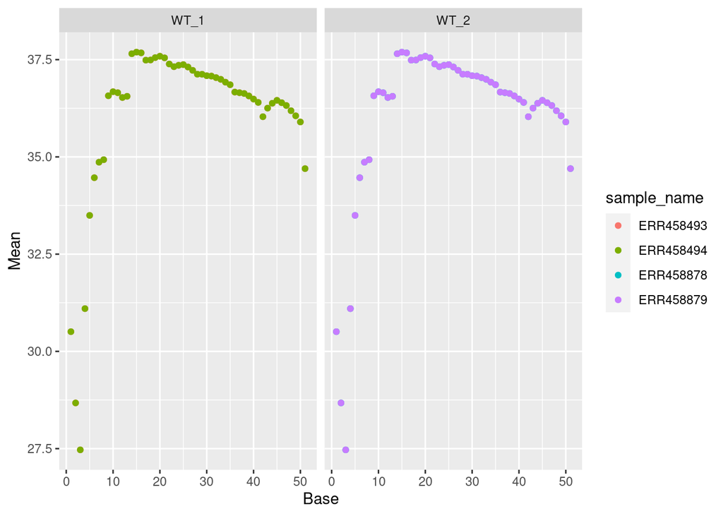

```r
sample_groups <- paste0(samples$Sample, '_', samples$BiolRep)
names(sample_groups) <- samples$RunAccession

fastqc_plotr_sample_df <- df %>%
   mutate(sample_group = sample_groups[sample_name])

# usethis::use_data(fastqc_plotr_sample_df)

fastqc_plotr_sample_df %>%
   plot_per_base_seq_qual()
```

For comparison, we can see the data accompanying the package will produce the same plot.

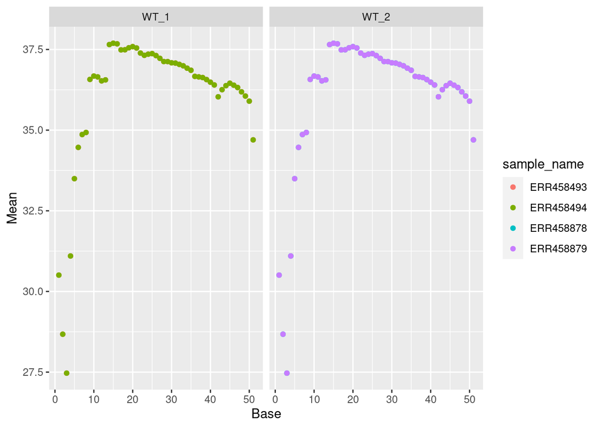

```r
FastQCPlotR::fastqc_plotr_sample_df %>%
   plot_per_base_seq_qual()
```